# La correlación entre las inmigraciones y los índices de violencia en México

## **Obtención de Muestra**

- La inseguridad pública: causas y consecuencias.
- Víctimas, inculpados y sentenciados registrados.
- Encuesta Nacional de Migración.

## **Metodología**

Recopilar las bases de datos(formato .csv) de la página del Instituto Nacional de Estadística y Geografía(INEGI), Universidad Nacional Autónoma de México(UNAM) , para obtener indicadores de aumento de violencia en México.

## **Diagrama de Gantt**

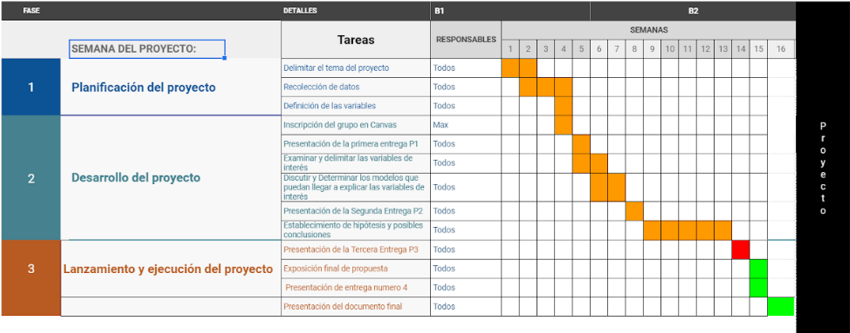

## **Referencias**

- Tapia Pérez, José (2013). La inseguridad pública: causas y consecuencias. El Cotidiano, (180),103-112.[fecha de Consulta 20 de Mayo de 2021]. ISSN: 0186-1840. Disponible en: https://www.redalyc.org/articulo.oa?id=32528338007
- Datos Abiertos de México - datos.gob.mx. (2021). Retrieved 10 May 2021, from https://datos.gob.mx/busca/dataset?tags=víctimas
- Biblioteca Los mexicanos vistos por sí mismos. Los grandes temas nacionales / Encuesta Nacional de Migración. (2021). Retrieved 10 May 2021, from http://www.losmexicanos.unam.mx/migracion/encuesta_nacional.html
- Morales Mena, A., & Caicedo, M. (2015, 25 agosto). Encuesta Nacional de Migración. Biblioteca Los Mexicanos vistos por sí mismos Los grandes temas nacionales. http://www.losmexicanos.unam.mx/migracion/encuesta_nacional.html https://datos.gob.mx/busca/dataset/migracion-mundial https://www.kaggle.com/zikazika/analysis-of-world-crime?select=Enrolment_in_Grade_1_of_primary_education1.csv
- Muñoz Rincón, D. (2021). ¿Cómo se dice:. Retrieved 17 May 2021, from https://www.upb.edu.co/es/central-blogs/ortografia/como-se-dice-migrante-emigrante-inmigrante
- Violencia. (2021). Retrieved 17 May 2021, from https://www.who.int/topics/violence/es/
- INEGI Encuesta Nacional de Victimización y Percepción sobre Seguridad Pública 2019. (2019). Percepción sobre seguridad pública. INEGI. https://www.inegi.org.mx/temas/percepcion/